# 探索式資料分析

曾意儒 Yi-Ju Tseng

### 對應書本章節

[7 探索式資料分析](http://yijutseng.github.io/DataScienceRBook/eda.html)

## 大綱

- 什麼是探索式資料分析
- 量化的分析方式
- dplyr
- data.table

## 什麼是探索式資料分析

- 探索式資料分析 (**E**xploratory **D**ata **A**nalysis)
- 在資料量 大/雜/髒 的時候，探索式資料分析非常重要
- 運用**視覺化**、**基本的統計**等工具，反覆的探索**資料特性**，獲取資料所包含的資訊、結構和特點
- 在進行複雜或嚴謹的分析之前，必須要對資料有更多認識，才能訂定**對的資料分析方向**
- 通常**不需要**嚴謹的假設和細節呈現

### 探索式資料分析

- 分析各變數間的**關聯性**，看是否有預料之外的有趣發現
- 觀察資料內容是否符合預期，若否，檢查資料**是否有誤**
- 檢查資料是否符合分析前的假設

透過探索性分析來**調整分析的方向**，減少因分析方向錯誤所造成的時間浪費。

### 探索式資料分析 - 快速查看

首先安裝`funModeling`套件

```r
install.packages("funModeling")
```

並載入

```r
library(funModeling)
```

### 探索式資料分析 - 快速查看

用`df_status()`快速查看資料的完整程度，以內建的`heart_disease`資料為例：

```r
df_status(heart_disease)
```

| variable | q_zeros | p_zeros | q_na | p_na | q_inf | p_inf | type | unique |
| --- | --- | --- | --- | --- | --- | --- | --- | --- |
| age | 0 | 0.00 | 0 | 0.00 | 0 | 0 | integer | 41 |
| gender | 0 | 0.00 | 0 | 0.00 | 0 | 0 | factor | 2 |
| chest_pain | 0 | 0.00 | 0 | 0.00 | 0 | 0 | factor | 4 |
| resting_blood_pressure | 0 | 0.00 | 0 | 0.00 | 0 | 0 | integer | 50 |
| serum_cholestoral | 0 | 0.00 | 0 | 0.00 | 0 | 0 | integer | 152 |
| fasting_blood_sugar | 258 | 85.15 | 0 | 0.00 | 0 | 0 | factor | 2 |
| resting_electro | 151 | 49.83 | 0 | 0.00 | 0 | 0 | factor | 3 |
| max_heart_rate | 0 | 0.00 | 0 | 0.00 | 0 | 0 | integer | 91 |
| exer_angina | 204 | 67.33 | 0 | 0.00 | 0 | 0 | integer | 2 |
| oldpeak | 99 | 32.67 | 0 | 0.00 | 0 | 0 | numeric | 40 |
| slope | 0 | 0.00 | 0 | 0.00 | 0 | 0 | integer | 3 |
| num_vessels_flour | 176 | 58.09 | 4 | 1.32 | 0 | 0 | integer | 4 |
| thal | 0 | 0.00 | 2 | 0.66 | 0 | 0 | factor | 3 |
| heart_disease_severity | 164 | 54.13 | 0 | 0.00 | 0 | 0 | integer | 5 |
| exter_angina | 204 | 67.33 | 0 | 0.00 | 0 | 0 | factor | 2 |
| has_heart_disease | 0 | 0.00 | 0 | 0.00 | 0 | 0 | factor | 2 |

### 探索式資料分析 - 快速查看

用`plot_num()`快速畫直方圖，查看數值資料的分佈

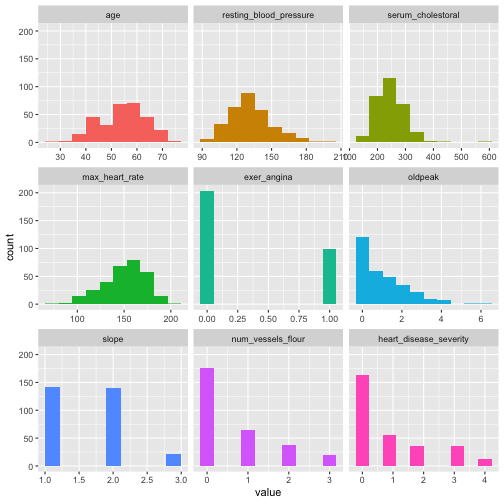

```r
plot_num(heart_disease)
```

### 探索式資料分析 - 快速查看

用`profiling_num()`快速查看資料的統計數字

```r
profiling_num(heart_disease)
```

| variable | mean | std_dev | variation_coef | p_01 | p_05 | p_25 | p_50 | p_75 | p_95 | p_99 | skewness | kurtosis | iqr | range_98 | range_80 |
| --- | --- | --- | --- | --- | --- | --- | --- | --- | --- | --- | --- | --- | --- | --- | --- |
| age | 54.44 | 9.04 | 0.17 | 35 | 40 | 48 | 56.0 | 61.0 | 68.0 | 71.0 | -0.21 | 2.5 | 13.0 | [35, 71] | [42, 66] |
| resting_blood_pressure | 131.69 | 17.60 | 0.13 | 100 | 108 | 120 | 130.0 | 140.0 | 160.0 | 180.0 | 0.70 | 3.9 | 20.0 | [100, 180] | [110, 152] |
| serum_cholestoral | 246.69 | 51.78 | 0.21 | 149 | 175 | 211 | 241.0 | 275.0 | 326.9 | 406.7 | 1.13 | 7.4 | 64.0 | [149, 406.74] | [188.8, 308.8] |
| max_heart_rate | 149.61 | 22.88 | 0.15 | 95 | 108 | 134 | 153.0 | 166.0 | 181.9 | 192.0 | -0.53 | 2.9 | 32.5 | [95.02, 191.96] | [116, 176.6] |
| exer_angina | 0.33 | 0.47 | 1.44 | 0 | 0 | 0 | 0.0 | 1.0 | 1.0 | 1.0 | 0.74 | 1.6 | 1.0 | [0, 1] | [0, 1] |
| oldpeak | 1.04 | 1.16 | 1.12 | 0 | 0 | 0 | 0.8 | 1.6 | 3.4 | 4.2 | 1.26 | 4.5 | 1.6 | [0, 4.2] | [0, 2.8] |
| slope | 1.60 | 0.62 | 0.38 | 1 | 1 | 1 | 2.0 | 2.0 | 3.0 | 3.0 | 0.51 | 2.4 | 1.0 | [1, 3] | [1, 2] |
| num_vessels_flour | 0.67 | 0.94 | 1.39 | 0 | 0 | 0 | 0.0 | 1.0 | 3.0 | 3.0 | 1.18 | 3.2 | 1.0 | [0, 3] | [0, 2] |
| heart_disease_severity | 0.94 | 1.23 | 1.31 | 0 | 0 | 0 | 0.0 | 2.0 | 3.0 | 4.0 | 1.05 | 2.8 | 2.0 | [0, 4] | [0, 3] |

### 探索式資料分析 - 快速查看

用`cross_plot()`快速查看某欄位（類別）與某連續變項（年齡）的關係

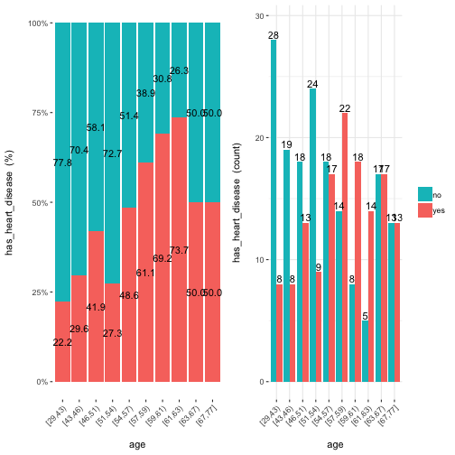

```r
cross_plot(heart_disease,
           input=c("age"),
           target="has_heart_disease")
```

### 探索式資料分析 - 快速查看

用`plotar()`快速查看某欄位（類別）與某連續變項（年齡）的關係

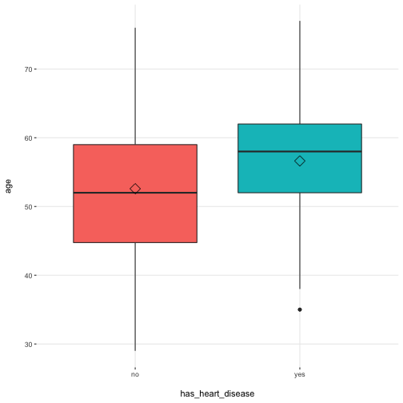

```r
plotar(data=heart_disease, input = c("age"),
       target="has_heart_disease",
       plot_type="boxplot")
```

### 探索式資料分析

- 圖形化Graphical
  - 單變量Univariate
  - 雙變量Bivariate
  - 多變量Multivariate
- 量化Quantitative
  - 單變量Univariate
  - 雙變量Bivariate
  - 多變量Multivariate

### 圖形化的分析

包括做圖與列表，將會在下章節介紹，本章節著重於量化的分析方式。

### 量化的分析方式: 單變量

資料初步統計，量化的分析方式可包含

- 計算集中趨勢
  - 平均值 Mean `mean()`
  - 中位數 Median `median()`
  - 眾數 Mode，R無內建函數，可直接用`table()`找出現次數最多的資料

### 量化的分析方式: 單變量-集中趨勢

```r
mean(iris$Sepal.Length)
```

```
[1] 5.8
```

```r
median(iris$Sepal.Length)
```

```
[1] 5.8
```

```r
table(iris$Species)
```

```
    setosa versicolor  virginica
        50         50         50
```

### 量化的分析方式: 單變量

資料初步統計，量化的分析方式可包含

- 計算資料分散程度
  - 最小值 Min `min()`
  - 最大值 Max `max()`
  - 範圍 Range `range()`
  - 四分位差 Quartiles `quantile()`
  - 變異數 Variance `var()`
  - 標準差 Standard deviation `sd()`

### 量化的分析方式: 單變量-分散程度

```r
min(iris$Sepal.Length)
```

```
[1] 4.3
```

```r
max(iris$Sepal.Length)
```

```
[1] 7.9
```

```r
range(iris$Sepal.Length)
```

```
[1] 4.3 7.9
```

### 量化的分析方式: 單變量

```r
quantile(iris$Sepal.Length)
```

```
  0%  25%  50%  75% 100%
 4.3  5.1  5.8  6.4  7.9
```

```r
var(iris$Sepal.Length)
```

```
[1] 0.69
```

```r
sd(iris$Sepal.Length)
```

```
[1] 0.83
```

### 單變量分析練習

- 在mtcars資料集中，車子馬力(hp)的平均值？標準差？
- 在mtcars資料集中，幾個汽缸(cyl)的車子最多？
- 在mtcars資料集中，油耗(mpg)的四分位數是多少？

### 量化的分析方式: 雙變量

- 列聯表 Crosstabs `table()`, `prop.table()`
- 共變異數 Covariance `cov()` 用於衡量兩個變量的總體誤差，[維基百科](https://zh.wikipedia.org/wiki/%E5%8D%8F%E6%96%B9%E5%B7%AE)
- 相關性 Correlation `cor()`

### 量化的分析方式: 雙變量-列聯表

汽缸的數目與自手排的關係

```r
table(mtcars$cyl,mtcars$am)
```

```
     0  1
  4  3  8
  6  4  3
  8 12  2
```

### 量化的分析方式: 雙變量-列聯表

```r
mtTable<-table(mtcars$cyl,mtcars$am)
prop.table(mtTable)
```

```
        0     1
  4 0.094 0.250
  6 0.125 0.094
  8 0.375 0.062
```

### 量化的分析方式: 雙變量-列聯表

```r
prop.table(mtTable,margin = 1)
```

```
       0    1
  4 0.27 0.73
  6 0.57 0.43
  8 0.86 0.14
```

```r
prop.table(mtTable,margin = 2)
```

```
       0    1
  4 0.16 0.62
  6 0.21 0.23
  8 0.63 0.15
```

### 量化的分析方式: 雙變量-共變異數

```r
cov(mtcars)
```

|  | mpg | cyl | disp | hp | drat | wt | qsec | vs | am | gear | carb |
| --- | --- | --- | --- | --- | --- | --- | --- | --- | --- | --- | --- |
| mpg | 36 | -9.2 | -633 | -321 | 2.2 | -5.1 | 4.5 | 2.0 | 1.8 | 2.1 | -5.4 |
| cyl | -9 | 3.2 | 200 | 102 | -0.7 | 1.4 | -1.9 | -0.7 | -0.5 | -0.6 | 1.5 |
| disp | -633 | 199.7 | 15361 | 6721 | -47.1 | 107.7 | -96.1 | -44.4 | -36.6 | -50.8 | 79.1 |
| hp | -321 | 101.9 | 6721 | 4701 | -16.5 | 44.2 | -86.8 | -25.0 | -8.3 | -6.4 | 83.0 |
| drat | 2 | -0.7 | -47 | -16 | 0.3 | -0.4 | 0.1 | 0.1 | 0.2 | 0.3 | -0.1 |
| wt | -5 | 1.4 | 108 | 44 | -0.4 | 1.0 | -0.3 | -0.3 | -0.3 | -0.4 | 0.7 |
| qsec | 4 | -1.9 | -96 | -87 | 0.1 | -0.3 | 3.2 | 0.7 | -0.2 | -0.3 | -1.9 |
| vs | 2 | -0.7 | -44 | -25 | 0.1 | -0.3 | 0.7 | 0.3 | 0.0 | 0.1 | -0.5 |
| am | 2 | -0.5 | -37 | -8 | 0.2 | -0.3 | -0.2 | 0.0 | 0.2 | 0.3 | 0.0 |
| gear | 2 | -0.6 | -51 | -6 | 0.3 | -0.4 | -0.3 | 0.1 | 0.3 | 0.5 | 0.3 |
| carb | -5 | 1.5 | 79 | 83 | -0.1 | 0.7 | -1.9 | -0.5 | 0.0 | 0.3 | 2.6 |

### 量化的分析方式: 雙變量-相關性

油耗跟馬力的關聯性（相關係數）

```r
cor(mtcars$mpg,mtcars$hp)
```

```
[1] -0.8
```

### 雙變量分析練習

- 在airquality資料集中，氣溫Temp和臭氧濃度Ozone的相關係數是多少？
- 在mtcars資料集中，各汽缸數cyl中，各類前進檔數gear的比例是多少

### 量化的分析方式 w/ R

- 大多可用R的內建函數完成計算
- 但是在探索式分析時，常常需要**資料分組**
  - 觀察**男性**和**女性**的血壓差異
  - **A隊**與**B隊**的三分球命中率差異
  - **中鋒**和**後衛**的助攻次數
  - …等
- 若只用基本的內建函數計算，相當耗時
  - `data.table`和`dplyr` packages可以快速完成**分組分析**!

## dplyr

- [Hadley Wickham](http://hadley.nz/)開發
- 使用以下函數分析整理資料：
  - `select()`: 選要分析的欄位，欄位子集 (Column)
  - `filter()`: 選要分析的觀察值，觀察值子集 (Row)
  - `mutate()`: 增加新欄位
  - `summarise()`: 計算統計值

## dplyr

- 使用以下函數分析整理資料：
  - `group_by()`: 分組依據
  - `arrange()`: 觀察值排序
  - `rename()`: 欄位重新命名
  - `%>%`: the “pipe” operator 連結上數函式，將所有函式計算串在一起執行

### dplyr

如要使用必須安裝並載入`dplyr` package

```r
install.packages("dplyr") ##安裝
```

```r
library(dplyr) ##載入
```

以NBA資料為例，首先先讀入資料

```r
library(SportsAnalytics)
NBA1718<-fetch_NBAPlayerStatistics("17-18")
```

### 增加新欄位 mutate()

- 新增新欄位`FGRate`，欄位值為`FieldGoalsMade/FieldGoalsAttempted`

```r
mutate1<-
    mutate(NBA1718,
           FGRate=FieldGoalsMade/FieldGoalsAttempted)
mutate1$FGRate[1:5]
```

```
[1] 0.4 0.4 0.6 0.5 0.4
```

### 計算統計值 summarise()

- **球員個數**、**不重複的隊伍數**以及**不重複的守備位置數**等
- n(), n_distinct()

```r
summarise(NBA1718,
          nPlayer=n(),
          nTeam=n_distinct(Team),
          nPos=n_distinct(Position))
```

```
  nPlayer nTeam nPos
1     540    33    6
```

### 計算統計值 summarise()

- 通常會與其他功能合併使用
- 計算**出場分鐘數大於2500分鐘**的**球員個數**、**平均投進的兩分球數**以及**平均投出的兩分球數**

```r
filter1<-filter(NBA1718,TotalMinutesPlayed>2500)
summarise(filter1,
          nPlayer=n(),
          meanFGMade=mean(FieldGoalsMade),
          meanFGAtt=mean(FieldGoalsAttempted))
```

```
  nPlayer meanFGMade meanFGAtt
1      33        569      1208
```

### dplyr filter()+summarise() 練習

- 讀入NBA資料

```r
library(SportsAnalytics)
library(dplyr)
NBA1718<-fetch_NBAPlayerStatistics("17-18")
```

- 試著用dplyr語法篩選出所有**助攻數(Assists)超過100**且**抄截數大於20**的球員資料
- 計算這些球員的**平均出場數GamesPlayed**，**平均出場分鐘數TotalMinutesPlayed**

### pipe %>%

- 直接用**pipe**符號`%>%`將指令串連，減少暫存物件（filter1）的生成

```r
filter(NBA1718,TotalMinutesPlayed>2500) %>%
    summarise(nPlayer=n(),
        meanFGMade=mean(FieldGoalsMade),
        meanFGAtt=mean(FieldGoalsAttempted))
```

```
  nPlayer meanFGMade meanFGAtt
1      33        569      1208
```

### dplyr pipe %>% 練習

- 讀入NBA資料

```r
library(SportsAnalytics)
NBA1718<-fetch_NBAPlayerStatistics("17-18")
library(dplyr)
```

- 試著用dplyr語法篩選出所有**助攻數(Assists)超過100**且**抄截數大於20**的球員資料
- 計算這些球員的**平均出場數GamesPlayed**，**平均出場分鐘數TotalMinutesPlayed**
- 用pipe **%>%**

### 分組 group_by()

- 設定分組依據
- 與`summarise()`函式合併使用
- 計算各**隊**（以Team作為分組依據）的**球員數**、**平均投進的兩分球數**以及**平均投出的兩分球數**

```r
group_by(NBA1718,Team)%>%
    summarise(nPlayer=n(),
        meanFGMade=mean(FieldGoalsMade),
        meanFGAtt=mean(FieldGoalsAttempted))
```

| Team | nPlayer | meanFGMade | meanFGAtt |
| --- | --- | --- | --- |
| ATL | 19 | 140 | 314 |
| BOS | 19 | 171 | 377 |
| BRO | 18 | 167 | 382 |
| CHA | 17 | 191 | 423 |

### 分組 group_by()

- 可設定**多個**分組依據
- 計算各**隊**各**守備位置**（以Team和Position作為分組依據）的**球員數**、**平均投進的兩分球數**以及**平均投出的兩分球數**

```r
group_by(NBA1718,Team,Position)%>%
  summarise(nPlayer=n(),
        meanFGMade=mean(FieldGoalsMade),
        meanFGAtt=mean(FieldGoalsAttempted))
```

| Team | Position | nPlayer | meanFGMade | meanFGAtt |
| --- | --- | --- | --- | --- |
| ATL | C | 2 | 178 | 328 |
| ATL | PF | 3 | 175 | 337 |
| ATL | PG | 4 | 197 | 466 |

### 排序 arrange()

排序功能，預設為**遞增排序**

```r
arrange(NBA1718,TotalMinutesPlayed)
```

| League | Name | Team | Position | GamesPlayed | TotalMinutesPlayed | FieldGoalsMade | FieldGoalsAttempted | ThreesMade | ThreesAttempted | FreeThrowsMade | FreeThrowsAttempted | OffensiveRebounds | TotalRebounds | Assists | Steals | Turnovers | Blocks | PersonalFouls | Disqualifications | TotalPoints | Technicals | Ejections | FlagrantFouls | GamesStarted |
| --- | --- | --- | --- | --- | --- | --- | --- | --- | --- | --- | --- | --- | --- | --- | --- | --- | --- | --- | --- | --- | --- | --- | --- | --- |
| NBA | Chris Boucher | GSW | PF | 1 | 1 | 0 | 1 | 0 | 1 | 0 | 0 | 0 | 1 | 0 | 0 | 0 | 0 | 0 | 0 | 0 | 0 | 0 | 0 | 0 |
| NBA | Trey Mckinney | IND | SG | 1 | 1 | 0 | 0 | 0 | 0 | 0 | 0 | 0 | 0 | 0 | 0 | 0 | 0 | 0 | 0 | 0 | 0 | 0 | 0 | 0 |
| NBA | Naza Mitrou-long | UTA | PF | 1 | 1 | 1 | 1 | 1 | 1 | 0 | 0 | 0 | 0 | 0 | 0 | 0 | 0 | 0 | 0 | 3 | 0 | 0 | 0 | 0 |
| NBA | Minda Kuzminskas | NYK | PF | 1 | 2 | 0 | 2 | 0 | 0 | 0 | 0 | 0 | 0 | 0 | 0 | 0 | 0 | 0 | 0 | 0 | 0 | 0 | 0 | 0 |
| NBA | Tyler Lydon | DEN | PF | 1 | 2 | 0 | 0 | 0 | 0 | 0 | 0 | 0 | 0 | 0 | 0 | 0 | 0 | 0 | 0 | 0 | 0 | 0 | 0 | 0 |
| NBA | Edmond Sumner | IND | PG | 1 | 2 | 1 | 1 | 0 | 0 | 0 | 0 | 0 | 1 | 0 | 0 | 0 | 0 | 1 | 0 | 2 | 0 | 0 | 0 | 0 |

### 遞減排序 arrange()

使用`desc()`將要**遞減排序**的變數包起來，就可以遞減排序

```r
arrange(NBA1718,
        desc(TotalMinutesPlayed),
        desc(GamesPlayed))
```

| League | Name | Team | Position | GamesPlayed | TotalMinutesPlayed | FieldGoalsMade | FieldGoalsAttempted | ThreesMade | ThreesAttempted | FreeThrowsMade | FreeThrowsAttempted | OffensiveRebounds | TotalRebounds | Assists | Steals | Turnovers | Blocks | PersonalFouls | Disqualifications | TotalPoints | Technicals | Ejections | FlagrantFouls | GamesStarted |
| --- | --- | --- | --- | --- | --- | --- | --- | --- | --- | --- | --- | --- | --- | --- | --- | --- | --- | --- | --- | --- | --- | --- | --- | --- |
| NBA | Lebron James | CLE | SF | 82 | 3024 | 857 | 1580 | 149 | 406 | 388 | 531 | 97 | 711 | 747 | 117 | 348 | 71 | 135 | 0 | 2251 | 6 | 0 | 0 | 82 |
| NBA | Khris Middleton | MIL | SF | 82 | 2980 | 593 | 1271 | 146 | 406 | 320 | 362 | 45 | 427 | 328 | 118 | 191 | 21 | 270 | 1 | 1652 | 4 | 0 | 0 | 82 |
| NBA | Andrew Wiggins | MIN | SG | 82 | 2979 | 569 | 1300 | 112 | 338 | 202 | 314 | 81 | 357 | 160 | 91 | 138 | 52 | 163 | 1 | 1452 | 0 | 0 | 0 | 82 |

### dplyr綜合範例

- 結合`group_by()`、`summarise()`、`arrange()`，可完成一連串的資料分析
- 計算各**隊**各**守備**位置（以Team和Position作為分組依據）的球員數、平均投進的兩分球數以及平均投出的兩分球數，並依平均投進的兩分球數**由大到小排序**

```r
group_by(NBA1718,Team,Position) %>%
  summarise(nPlayer=n(),
    meanFGMade=mean(FieldGoalsMade),
    meanFGAtt=mean(FieldGoalsAttempted)) %>%
  arrange(desc(meanFGMade))
```

| Team | Position | nPlayer | meanFGMade | meanFGAtt |
| --- | --- | --- | --- | --- |
| PHI | C | 1 | 510 | 1053 |
| MIA | PG | 1 | 484 | 1075 |
| MIL | SF | 3 | 473 | 954 |

### 修改欄位名稱 rename()

`新名稱=舊名稱`

```r
rename1<-rename(NBA1718,Po=Position)
rename1[1:5,1:5]
```

```
  League          Name Team Po GamesPlayed
1    NBA  Alex Abrines  OKL SG          74
2    NBA    Quincy Acy  BRO SF          70
3    NBA  Steven Adams  OKL  C          76
4    NBA   Bam Adebayo  MIA PF          69
5    NBA Arron Afflalo  ORL SG          52
```

### dplyr 綜合練習

- 讀入NBA資料

```r
library(SportsAnalytics)
library(dplyr)
NBA1718<-fetch_NBAPlayerStatistics("17-18")
```

- 試著用dplyr語法篩選出所有**助攻數(Assists)超過100**且**抄截數大於20**的球員資料
- 依**守備位置**Position分組，計算球員的平均**出場數**GamesPlayed，平均**出場分鐘數**TotalMinutesPlayed
- 依平均出場數GamesPlayed**由大到小**排序
- 用pipe **%>%**

### dplyr 參考文件與資源

- [Introduction to dplyr](https://cran.rstudio.com/web/packages/dplyr/vignettes/introduction.html)
- DataCamp互動式教學課程 [Data Manipulation in R with dplyr](https://www.datacamp.com/courses/dplyr-data-manipulation-r-tutorial)